# Prediction

# 2. Log2(%CD4/%CD8) at visit 2 vs. log2(valerate/propionate) at visit 1

1. Reduction in propionic acid relative to valeric acid reduces CD4 counts relative to CD8 among seroconverters more quickly than among controls.
2. P-value is obtained from linear regression model adjusting for age.

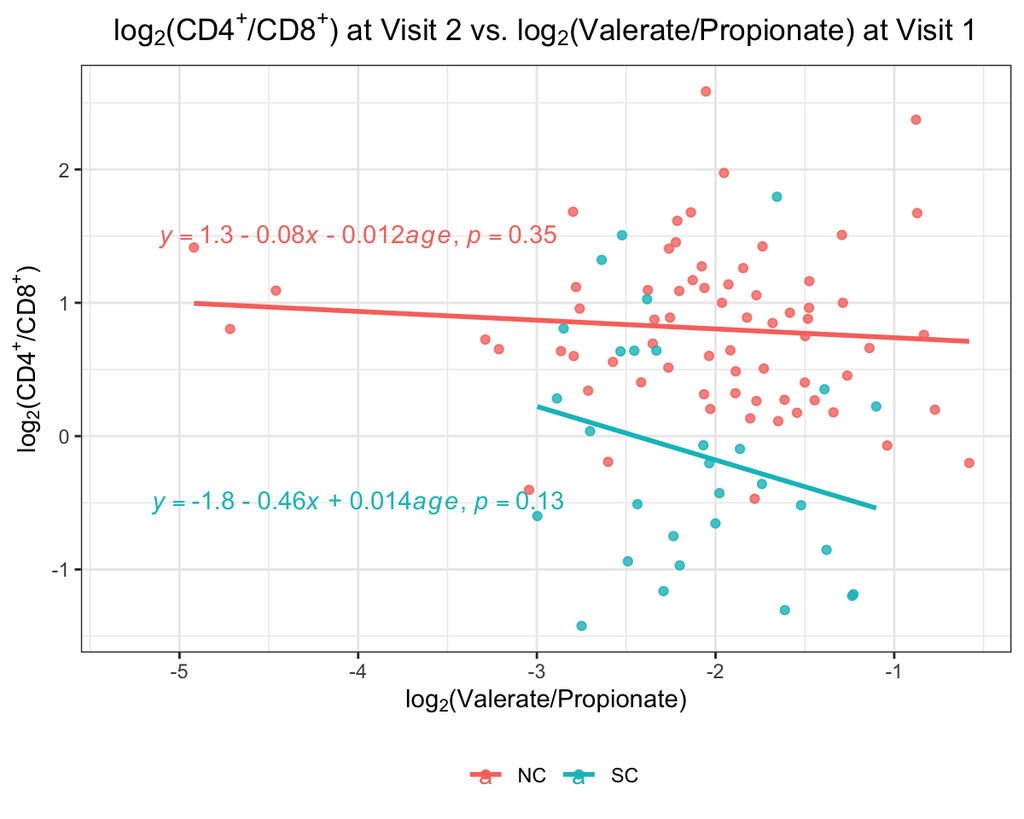

```r
df_fig2.1 = df_wide %>%
  transmute(subjid, status, age,
            cd4 = v2_leu3p, cd8 = v2_leu2p,
            valerate = v1_valerate, propionate = v1_propionate,
            ratio1 = log(cd4/cd8, base = 2),
            ratio2 = log(valerate/propionate, base = 2))

df_lm = df_fig2.1 %>%
  group_by(status) %>%
  do(fit = lm(formula = ratio1 ~ ratio2 + age, data = .)) %>%
  summarise(eq = lm_eqn(m = fit))

df_ann = df_fig2.1 %>%
  group_by(status) %>%
  summarise(ratio = 1, shannon = 0) %>%
  mutate(eq = df_lm$eq,
         x = c(-4, -4), y = c(1.5, -0.5), status = c("nc", "sc"))

p = ggplot(data = df_fig2.1, aes(x = ratio2, y = ratio1, color = status)) +
  geom_point(alpha = 0.8) +
  geom_smooth(method = "lm", se = FALSE) +
  scale_color_discrete(name = NULL, label = c("nc" = "NC", "sc" = "SC")) +
  geom_text(data = df_ann, aes(x = x, y = y, label = eq, color = status),
            parse = TRUE, inherit.aes = FALSE) +
  labs(x = expression(paste(log[2], "(Valerate/Propionate)")),
       y = expression(paste(log[2], "(", CD4^{"+"}, "/", CD8^{"+"}, ")")),
       title = expression(paste(log[2], "(", CD4^{"+"}, "/", CD8^{"+"}, ") at Visit 2 vs. ",
                                log[2], "(Valerate/Propionate) at Visit 1"))) +
  theme_bw() +
  theme(strip.background = element_rect(fill = "white"),
        legend.position = "bottom",
        plot.title = element_text(hjust = 0.5))
p
```

# 3. Microbiome

## 3.1 Log2(prevotellaceae/bacteroidaceae) at visit 1 vs. status.

1. Absolute abundance of prevotellaceae relative to bacteroidaceae at visit 1 is highly correlated with seroconversion at a future visit.
2. P-value is obtained by ANCOVA test adjusting for age.

```r
df_fig3.1_raw = df_wide %>%
  transmute(subjid, status, age,
            prev = v1_Prevotellaceae,
            bact = v1_Bacteroidaceae,
            ratio = log(prev/bact, base = 2)) %>%
  filter(is.finite(ratio))

df_fig3.1 = df_fig3.1_raw %>%
  group_by(status) %>%
  summarise(ratio = mean(ratio, na.rm = TRUE))

tab3.1 = df_fig3.1
col_name = c("Status", "Log2(Prevotellaceae/Bacteroidaceae)")
colnames(tab3.1) = col_name
tab3.1 %>%
  datatable(caption = "Log2(Prevotellaceae/Bacteroidaceae) at Visit 1 vs. Status") %>%
  formatRound(col_name[-1], digits = 2)
```

|  | Status | Log2(Prevotellaceae/Bacteroidaceae) |
| --- | --- | --- |
| 1 | nc | 1.44835634776109 |
| 2 | sc | 3.21749594877193 |

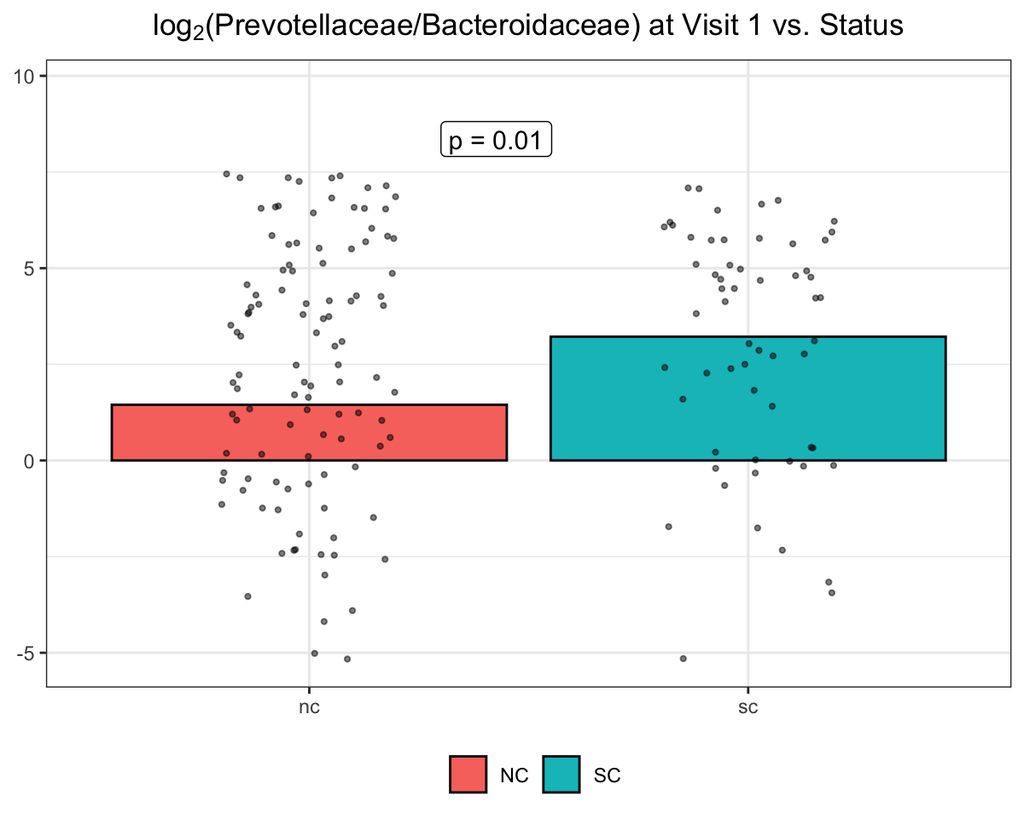

```r
df_jitter = df_fig3.1_raw %>%
  filter(ratio >= quantile(ratio, 0.1, na.rm = TRUE) &
           ratio <= quantile(ratio, 0.9, na.rm = TRUE))

df_ann = data.frame(x = 1.3,
                    y = max(df_jitter$ratio, na.rm = TRUE),
                    y_max = 1.3 * max(df_jitter$ratio, na.rm = TRUE),
                    status = "nc", ratio = 1,
                    p = anova_test(data = df_fig3.1_raw,
                                   formula = ratio ~ status + age)$p[1]) %>%
  mutate(label = paste0("p = ", signif(p, 2)))

p = ggplot(data = df_fig3.1, aes(x = status, y = ratio)) +
  geom_col(color = "black", aes(fill = status)) +
  geom_jitter(position = position_jitter(0.2), data = df_jitter,
              alpha = 0.5, size = 0.8) +
  labs(x = NULL, y = NULL,
       title = expression(paste(log[2], "(Prevotellaceae/Bacteroidaceae) at Visit 1 vs. Status"))) +
  scale_fill_discrete(name = NULL,
                      label = c("nc" = "NC", "sc" = "SC")) +
  geom_blank(data = df_ann, aes(y = y_max)) +
  geom_label(data = df_ann, aes(x = x, y = y, label = label),
             size = 4, vjust = -0.5, hjust = 0, color = "black") +
  theme_bw() +
  theme(legend.position = "bottom",
        plot.title = element_text(hjust = 0.5))
p
```

## 3.2 Correlations between significant families and pro-inflammatory cytokines at visit 1

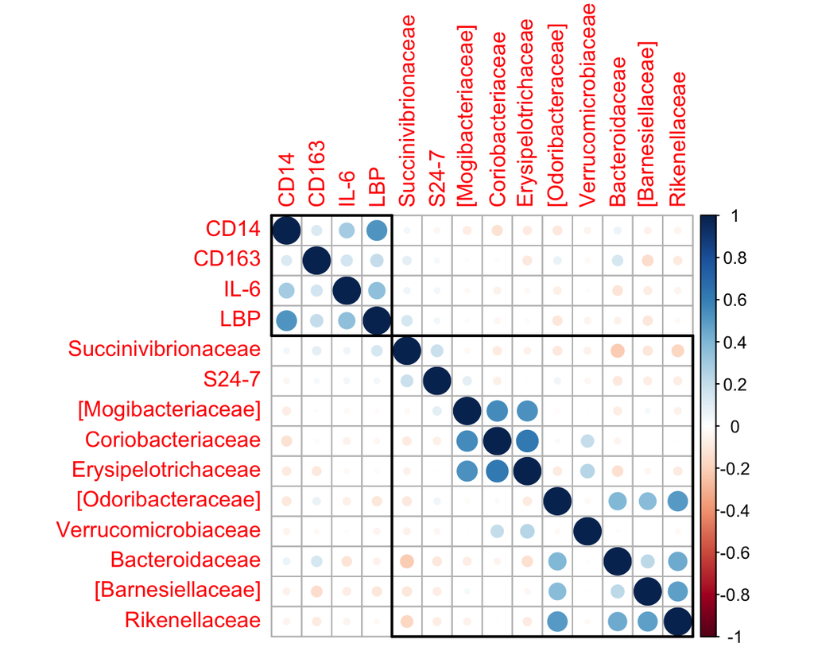

```r
df_fig3.2_raw = df %>%
  dplyr::select(-Prevotellaceae, -Bacteroidaceae) %>%
  left_join(df_family, by = "sampleid") %>%
  filter(visit == "v1") %>%
  transmute(status, CD14 = cd14, CD163 = cd163, `IL-6` = il6, LBP = lbp,
            Succinivibrionaceae, `S24-7`, `[Mogibacteriaceae]`,
            Coriobacteriaceae, Erysipelotrichaceae, `[Odoribacteraceae]`,
            Verrucomicrobiaceae, Bacteroidaceae, `[Barnesiellaceae]`,
            Rikenellaceae)

df_fig3.2_nc = df_fig3.2_raw %>%
  filter(status == "nc") %>%
  dplyr::select(-status) %>%
  mutate_if(is.numeric, scale)

df_fig3.2_sc = df_fig3.2_raw %>%
  filter(status == "sc") %>%
  dplyr::select(-status) %>%
  mutate_if(is.numeric, scale) %>%
  mutate_if(is.numeric, scale)

# NC
mat_cor_nc = round(cor(df_fig3.2_nc, use = "complete.obs"), 2)

corrplot(mat_cor_nc, method = "circle") %>%
  corrRect(index = c(1, 5, 14))
```

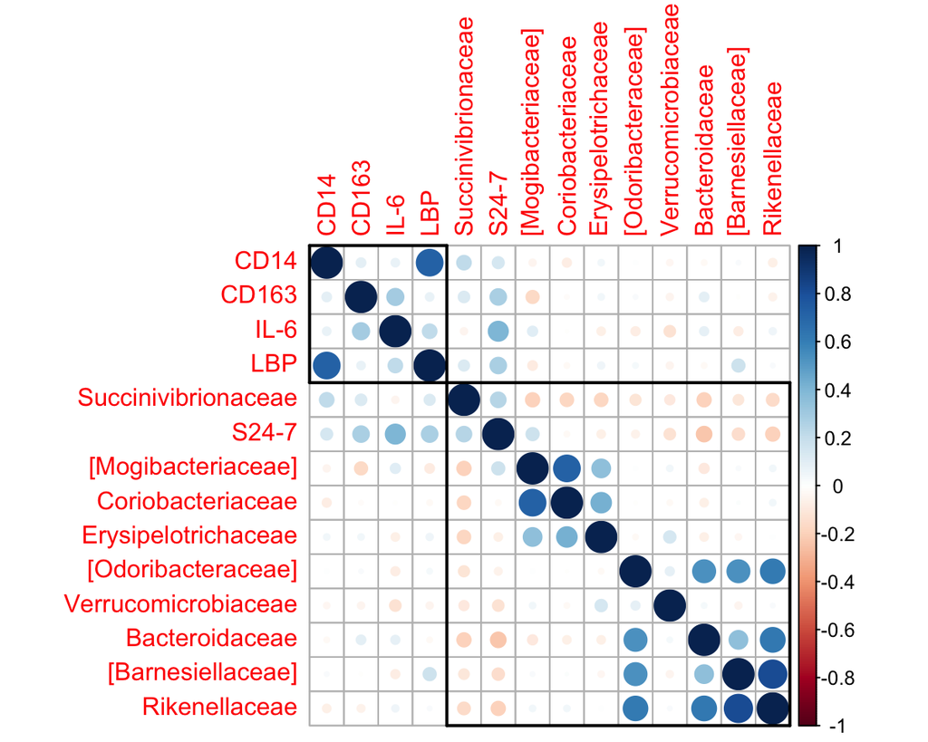

```r
# SC
mat_cor_sc = round(cor(df_fig3.2_sc, use = "complete.obs"), 2)

corrplot(mat_cor_sc, method = "circle") %>%
  corrRect(index = c(1, 5, 14))
```

# 4. Prediction model

```r
df_fig4 = df_wide %>%
  transmute(subjid, status, age,
            shannon = v1_shannon,
            vale = ifelse(v1_valerate == 0, NA, log(v1_valerate, base = 2)),
            prop = ifelse(v1_propionate == 0, NA, log(v1_propionate, base = 2)),
            prev = ifelse(v1_Prevotellaceae == 0, NA, log(v1_Prevotellaceae, base = 2)),
            bact = ifelse(v1_Bacteroidaceae == 0, NA, log(v1_Bacteroidaceae, base = 2)),
            ratio1 = prev - bact,
            ratio2 = vale - prop) %>%
  mutate(prob = ifelse(status == "sc", 1, 0))
df_fig4$status = factor(df_fig4$status)
```

## 4.1 Model 1: status (NC vs. SC) ~ age + alpha diversity + log2(prevotellaceae/bacteroidaceae) + log2(valerate/propionate)

```r
fit1 = glm(status ~ age + ratio1 + ratio2 + shannon,
           family = "binomial", data = df_fig4)
tab4.1 = rstatix::tidy(fit1)
tab4.1$term = c("Intercept", "Age", "Log2(Prevotellaceae/Bacteroidaceae)",
                "Log2(Valerate/Propionate)", "Shannon")
tab4.1 %>% datatable(caption = "Model 1") %>%
  formatRound(colnames(tab4.1)[-1], digits = 3)
```

|  | term | estimate | std.error | statistic | p.value |
| --- | --- | --- | --- | --- | --- |
| 1 | Intercept | -0.0377118392053661 | 0.99122266906825 | -0.0380457796035025 | 0.969651181585306 |
| 2 | Age | -0.0214883252788175 | 0.00999798867631818 | -2.14926481460376 | 0.0316134139870629 |
| 3 | Log2(Prevotellaceae/Bacteroidaceae) | 0.0840364462112173 | 0.038007502873144 | 2.21104886821168 | 0.0270324531849775 |
| 4 | Log2(Valerate/Propionate) | 0.122591020743487 | 0.211604246185301 | 0.579341024357963 | 0.562359089439313 |
| 5 | Shannon | 0.25987544722118 | 0.442197298536169 | 0.587691168809627 | 0.556739604273656 |

## 4.2 Model 2: status (NC vs. SC) ~ age + alpha diversity + log2(prevotellaceae/bacteroidaceae)

```r
fit2 = glm(status ~ age + ratio1 + shannon, family = "binomial", data = df_fig4)
tab4.2 = rstatix::tidy(fit2)
tab4.2$term = c("Intercept", "Age", "Log2(Prevotellaceae/Bacteroidaceae)", "Shannon")
tab4.2 %>% datatable(caption = "Model 2") %>%
  formatRound(colnames(tab4.2)[-1], digits = 3)
```

|  | term | estimate | std.error | statistic | p.value |
| --- | --- | --- | --- | --- | --- |
| 1 | Intercept | -0.656521419310826 | 0.794236062445062 | -0.826607416049228 | 0.408459612608449 |
| 2 | Age | -0.0247529042961828 | 0.00995563699264551 | -2.48632049505908 | 0.012907166662785 |
| 3 | Log2(Prevotellaceae/Bacteroidaceae) | 0.0988328052276262 | 0.0361112413111706 | 2.73689858445972 | 0.00620214099687454 |
| 4 | Shannon | 0.550570012825077 | 0.417831178153729 | 1.31768532749969 | 0.187609008266274 |

## 4.3 Model 3: status (NC vs. SC) ~ age + log2(prevotellaceae/bacteroidaceae)

```r
fit3 = glm(status ~ age + ratio1, family = "binomial", data = df_fig4)
tab4.3 = rstatix::tidy(fit3)
tab4.3$term = c("Intercept", "Age", "Log2(Prevotellaceae/Bacteroidaceae)")
tab4.3 %>% datatable(caption = "Model 3") %>%
  formatRound(colnames(tab4.3)[-1], digits = 3)
```

|  | term | estimate | std.error | statistic | p.value |
| --- | --- | --- | --- | --- | --- |
| 1 | Intercept | 0.231690981390735 | 0.41733887300619 | 0.555162713987822 | 0.578783369825259 |
| 2 | Age | -0.0239992269638096 | 0.00990715544174314 | -2.42241348739624 | 0.0154177963483125 |
| 3 | Log2(Prevotellaceae/Bacteroidaceae) | 0.0795856657474904 | 0.0317122650411692 | 2.50961782906933 | 0.0120861886016043 |

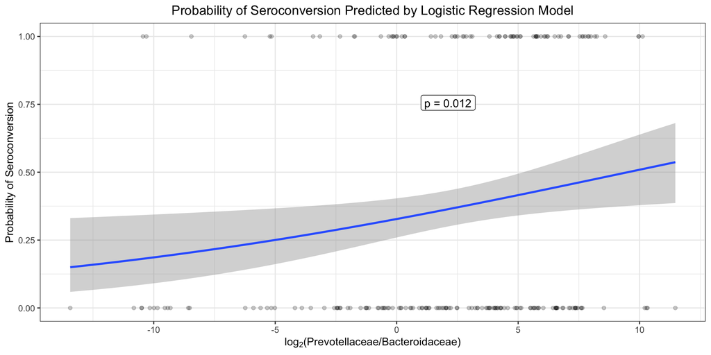

```r
df_fig4_long = df_fig4 %>%
  dplyr::select(subjid, prob, age, ratio1) %>%
  gather(key = "measure", value = "value", age:ratio1)
df_fig4_long$measure = recode(df_fig4_long$measure,
                              age = "Age",
                              ratio1 = "Log2(Prevotellaceae/Bacteroidaceae)")
df_fig4_long2 = df_fig4_long %>%
  filter(measure == "Log2(Prevotellaceae/Bacteroidaceae)")

df_ann = data.frame(measure = "Log2(Prevotellaceae/Bacteroidaceae)",
                    x = 1, y = 0.7, prob = 1,
                    p = coef(summary(fit3))["ratio1", "Pr(>|z|)"]) %>%
  mutate(label = paste0("p = ", signif(p, 2)))

p = df_fig4_long2 %>% ggplot(aes(x = value, y = prob)) +
  geom_point(alpha = 0.2) +
  geom_smooth(method = "glm", method.args = list(family = "binomial")) +
  labs(x = expression(paste(log[2], "(Prevotellaceae/Bacteroidaceae)")),
       y = "Probability of Seroconversion",
       title = "Probability of Seroconversion Predicted by Logistic Regression Model") +
  geom_label(data = df_ann, aes(x = x, y = y, label = label),
             size = 4, vjust = -0.5, hjust = 0, color = "black") +
  theme_bw() +
  theme(legend.position = "bottom",
        strip.background = element_rect(fill = "white"),
        plot.title = element_text(hjust = 0.5))
p
```